# Probabilidades

ProbEst

fnaufel

17/09/2021

# 1 Espaço amostral

- Conjunto de todos os *resultados* possíveis de uma iteração de um *experimento probabilístico* (uma *prova*).
- Exemplos
  1. Lançar uma moeda: $\{ K, C \}$
  2. Lançar 2 moedas: $\{ (K,K), (K,C), (C,K), (C,C) \}$
  3. Lançar um dado: $\{ 1, 2, 3, 4, 5, 6 \}$
  4. Lançar 2 dados: $\{ (1, 1), (1, 2), \ldots, (6, 5), (6, 6) \}$

# 2 Evento

- Um subconjunto do espaço amostral.
- Exemplos:
  1. Lançar uma moeda e obter cara: $\{ K \}$
  2. Lançar 2 moedas e obter resultados iguais: $\{ (K,K), (C,C) \}$
  3. Lançar um dado e obter um número maior que 4: $\{ 5, 6 \}$
  4. Lançar 2 dados e obter 2 números iguais: $\{ (1,1), (2,2), (3,3), (4,4), (5,5), (6,6) \}$

# 3 Análise combinatória

- Quantas senhas de 6 caracteres (dentre letras e dígitos) existem, sem distinguir entre minúsculas e maiúsculas?
- E se não puder haver repetição de caracteres?

# 4 Probabilidade clássica

- Cada resultado do espaço amostral tem a mesma chance de ocorrer.
- Para um evento $E$:
  $$P(E) = \frac{\text{Qtde de resultados em } E}{\text{Qtde de resultados no espaço amostral}}$$
- De um baralho normal, de 52 cartas, qual a probabilidade de escolher uma carta ao acaso e obter
  1. Uma carta de ouros?
  2. Uma carta vermelha?
  3. Uma carta de figura (J, Q ou K)?
  4. Uma carta de ouros, copas, paus ou espadas?
  5. Um carta de um naipe verde?

# 5 Probabilidade empírica (estatística)

- Baseada em repetições de um experimento probabilístico.
- A probabilidade de um evento é sua *frequência relativa*:
  $$P(E) = \frac{\text{Qtde de ocorrências de } E}{\text{Qtde total de repetições do experimento}}$$

### Lei dos grandes números

Quando o número $n$ de repetições de um experimento tende a infinito, a frequência relativa de um evento tende à sua probabilidade real.

```r
lancar <- function(lancamentos, n = 100) {

  moeda <- c('k', 'c')
  novos <- sample(moeda, n, replace = TRUE)
  c(lancamentos, novos)

}

plotar <- function(lancamentos) {

  n <- length(lancamentos)
  caras <- tibble(caras = cumsum(lancamentos == 'k')/(1:n))

  intervalo <- 10 ^ (ceiling(log10(n)) - 1)
  grafico <- caras %>%
    ggplot(aes(x = 1:n, y = caras)) +
      geom_line(color = 'blue') +
      scale_y_continuous(
        name = 'proporção\nde caras',
        breaks = seq(0, 1, 0.1),
        limits = c(0,1)
      ) +
      scale_x_continuous(
        name = 'lançamentos',
        breaks = seq(0, n, intervalo)
      )

  print(grafico)

}
```

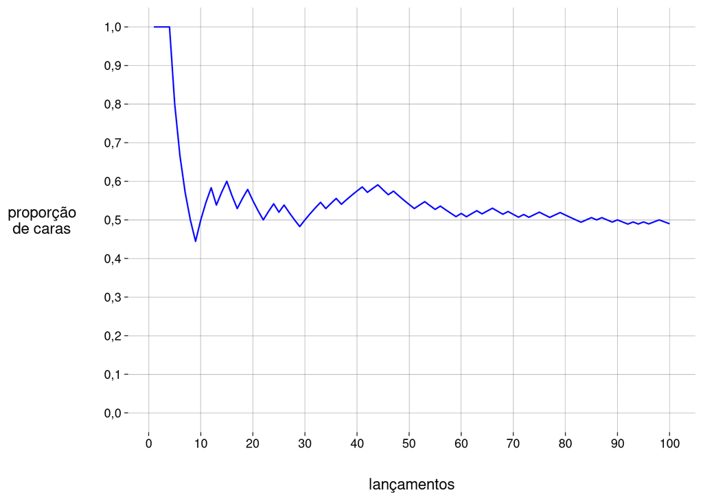

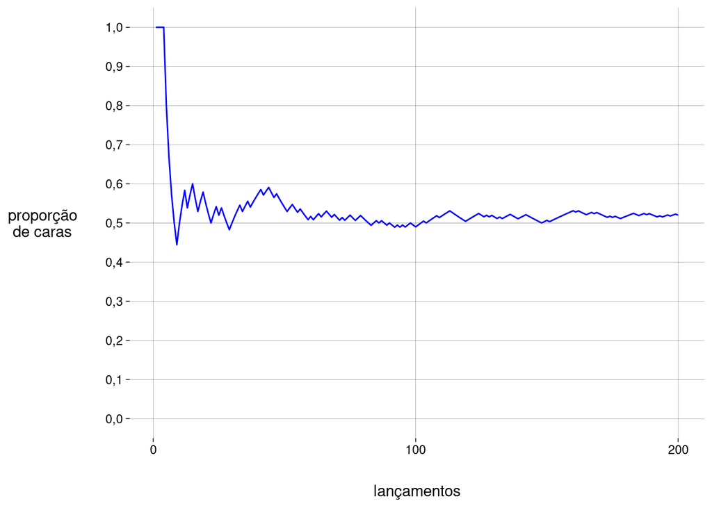

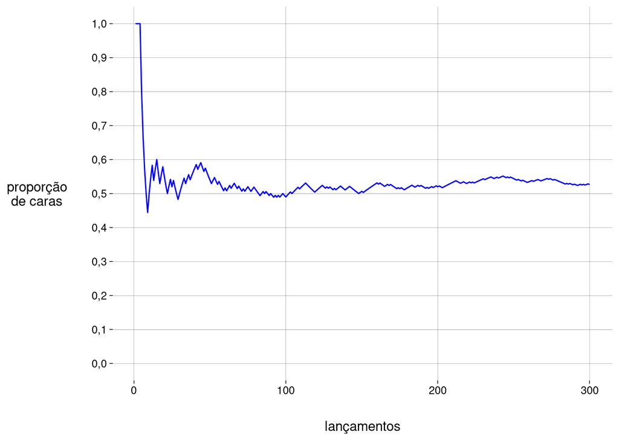

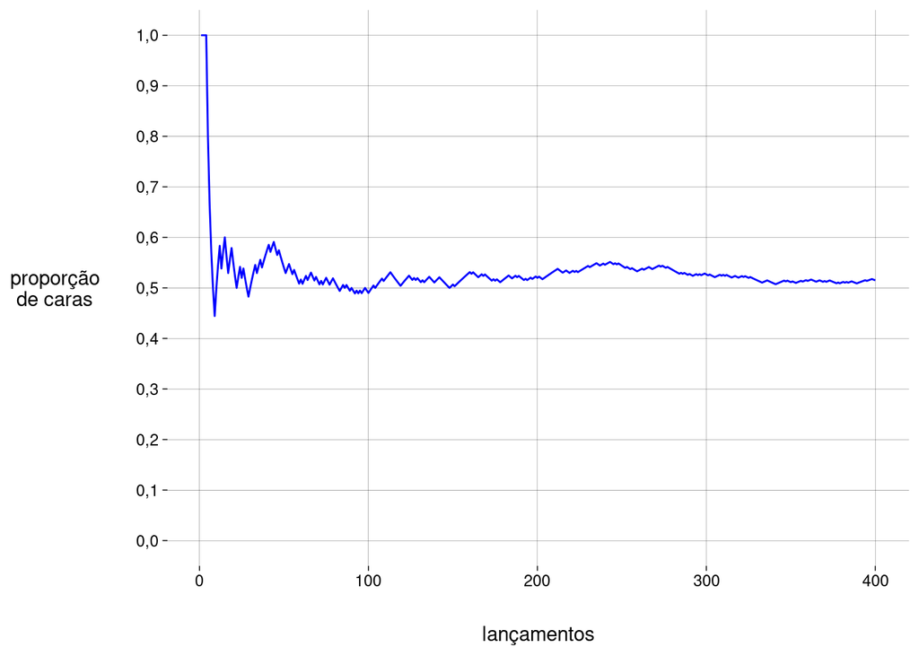

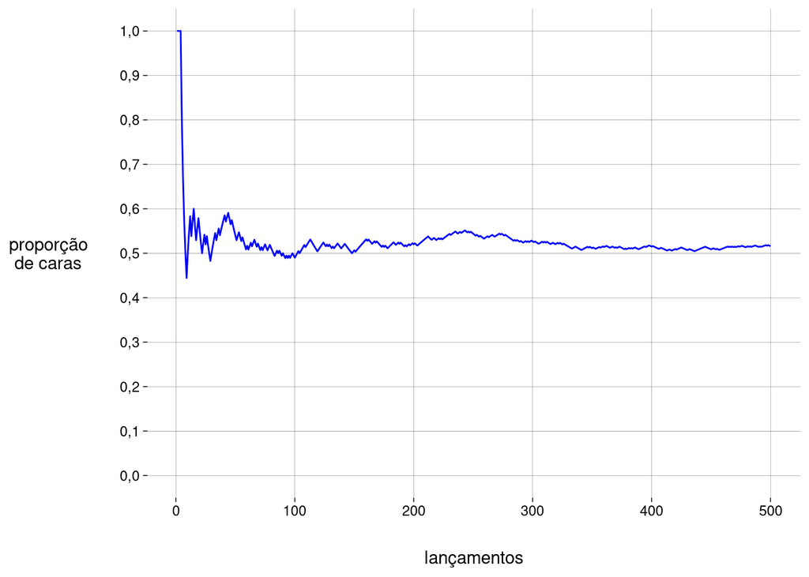

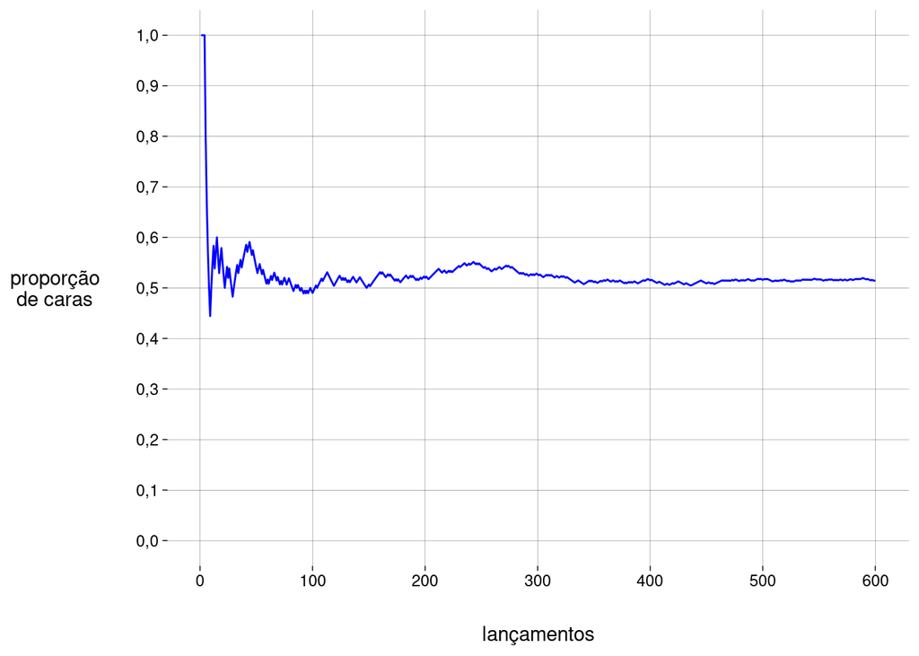

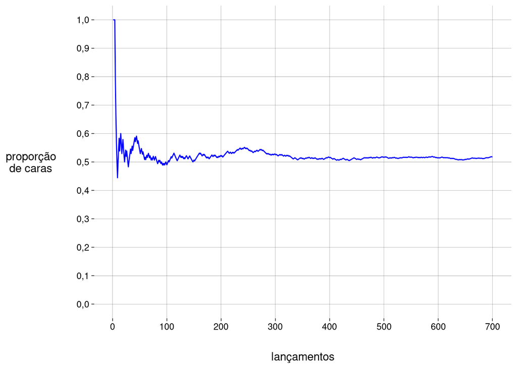

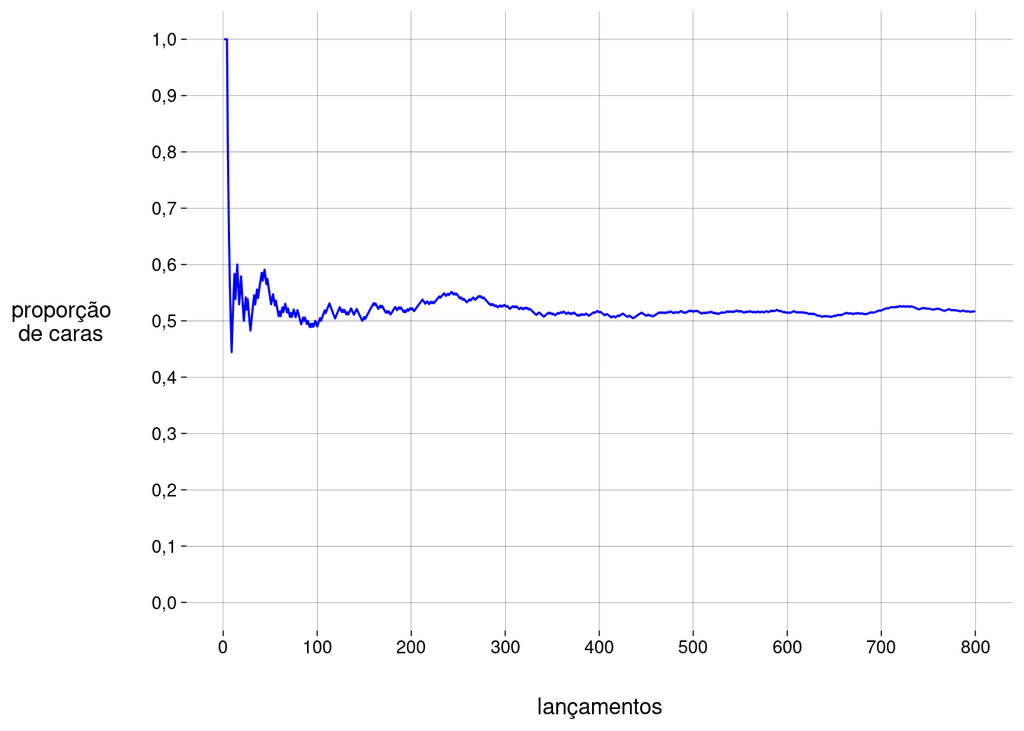

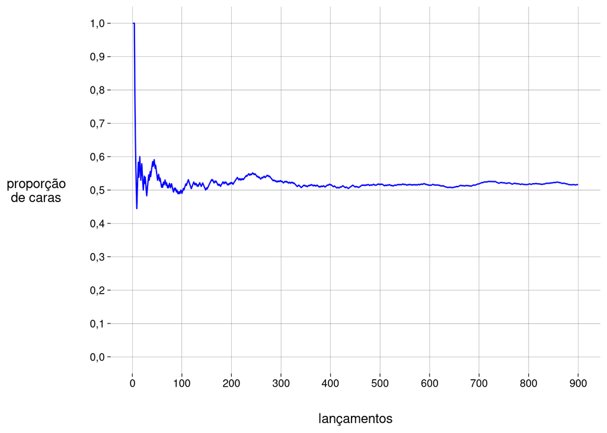

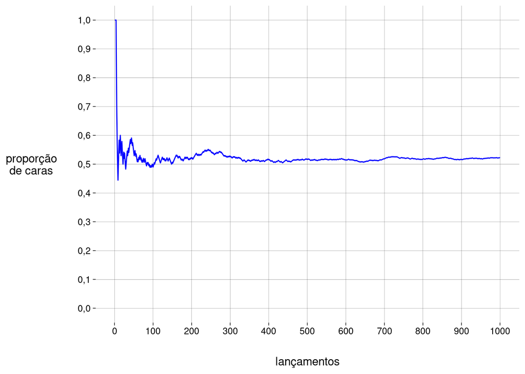

```r
resultados <- vector()

for (i in 1:10) {
  resultados <- lancar(resultados)
  plotar(resultados)
}
```

Isto **não** quer dizer que eventos que não acontecem há muito tempo têm probabilidade maior de acontecer no futuro próximo.

# 6 Probabilidade subjetiva

- Crença.
- Consistente com os valores que você estaria disposto a apostar contra alguém para que a aposta seja justa.

# 7 Formalização de probabilidades

1. $0 \leq P(A) \leq 1$, para qualquer evento $A$
2. $P(\Omega) = 1$, onde $\Omega$ é o espaço amostral
3. $P(\bar A) = 1 - P(A)$, onde $\bar A$ é o evento complementar de $A$ (i.e., o evento que corresponde a $A$ *não* ocorrer)
4. $P(A \cup B) = P(A) + P(B)$, onde $A$ e $B$ são eventos disjuntos (i.e., $A$ e $B$ não podem ocorrer ao mesmo tempo)

# 8 Eventos independentes (explicação informal)

A probabilidade de os eventos $A$ e $B$ acontecerem ao mesmo tempo é escrita como
$$P(A, B) \qquad \text{ou como} \qquad P(A \cap B)$$

Se a ocorrência de $A$ não influencia a ocorrência de $B$, nem vice-versa, dizemos que os eventos $A$ e $B$ são *independentes*.

Exemplo:

- O experimento é lançar um dado duas vezes.
- $A$ é o evento *o primeiro lançamento deu um número par*.
- $B$ é o evento *o segundo lançamento deu 6*.

Quando $A$ e $B$ são independentes,
$$P(A, B) = P(A) \cdot P(B)$$

# 9 $P(A \cup B)$ com $A$ e $B$ não-disjuntos

$$P(A \cup B) = P(A) + P(B) - P(A, B)$$

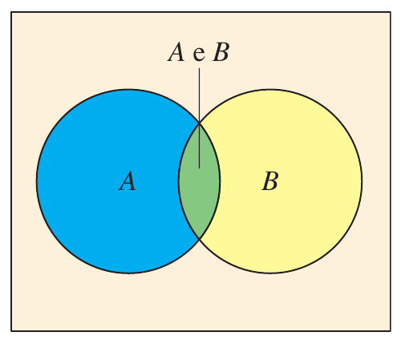

# 10 Problema do aniversário

Em uma sala estão 25 pessoas escolhidas ao acaso. Qual a probabilidade de que pelo menos 2 delas façam aniversário no mesmo dia do ano?

## 10.1 Premissas

- Os dias dos aniversários das pessoas são independentes.
- Cada dia do ano tem a mesma probabilidade de ser o aniversário de alguém.
- Vamos ignorar anos bissextos. Cada ano tem 365 dias.

## 10.2 Solução teórica

- Queremos achar $P(I)$, onde $I$ é o evento de que pelo menos duas pessoas têm aniversários iguais.
- Vamos calcular a probabilidade $P(N)$ de que *não* haja aniversários iguais.
- Este evento $N$ é o complementar do evento $I$, i.e., $N = \bar I$.
- Então, $P(I) = 1 - P(N)$.
- $P(N)$ é a probabilidade de que todos os aniversários caiam em dias diferentes:
  - A pessoa 1 pode ter nascido em qualquer dia do ano.
  - A pessoa 2 precisa ter nascido em algum dos outros 364 dias. A probabilidade deste evento é $\frac{364}{365}$.
  - A pessoa 3 precisa ter nascido em algum dos outros 363 dias. A probabilidade deste evento é $\frac{363}{365}$.
  - $\ldots$
  - A pessoa 25 precisa ter nascido em algum dos outros 341 dias. A probabilidade deste evento é $\frac{341}{365}$.
- Como os nascimentos são independentes, temos
  $$P(N) = \frac{364}{365} \cdot \frac{363}{365} \cdot \cdots \cdot \frac{341}{365}
  = \frac{364 \cdot 363 \cdot \cdots \cdot 341}{365^{24}}$$

```r
pn <- prod((364:341)/365)
pn
```

```
## [1] 0,4313003
```

- A resposta é

```r
1 - pn
```

```
## [1] 0,5686997
```

- Surpreso? Com 25 pessoas na sala, é mais provável haver do que não haver coincidência de aniversários!

## 10.3 Simulação

Vamos simular milhares de salas com 25 pessoas satisfazendo as premissas e ver em quantas delas há coincidência de aniversários:

```r
nsalas <- 1e4
npessoas <- 25

coincidencia <- function(sala) {

  !(length(unique(sala)) == length(sala))

}

testar_sala <- function(npessoas) {

  sala <- sample(1:365, npessoas, replace = TRUE)
  coincidencia(sala)

}

simular <- function(npessoas, nsalas) {

  resultados <- replicate(nsalas, testar_sala(npessoas))
  mean(resultados)

}

simular(npessoas, nsalas)
```

```
## [1] 0,5731
```

## 10.4 Para diferentes valores de $n \in \{2, 3, \ldots, 50\}$

### 10.4.1 Soluções teóricas

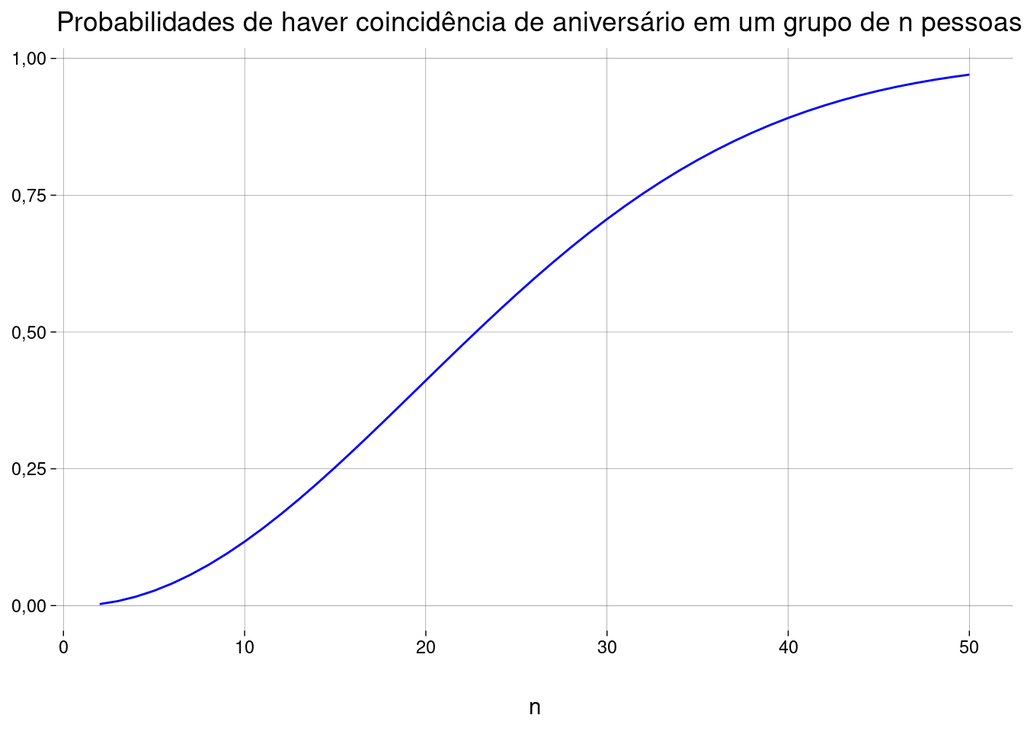

```r
npessoas <- 2:50

p <- function(n) {

  1 - prod((364:(366 - n))/365)

}

probs <- sapply(npessoas, p)

grafico <- probs %>%
  as_tibble() %>%
  ggplot(aes(x = npessoas, y = value)) +
    geom_line(color = 'blue') +
    labs(
      title = 'Probabilidades de haver coincidência de aniversário em um grupo de n pessoas',
      y = NULL,
      x = 'n'
    )

grafico
```

### 10.4.2 Simulação

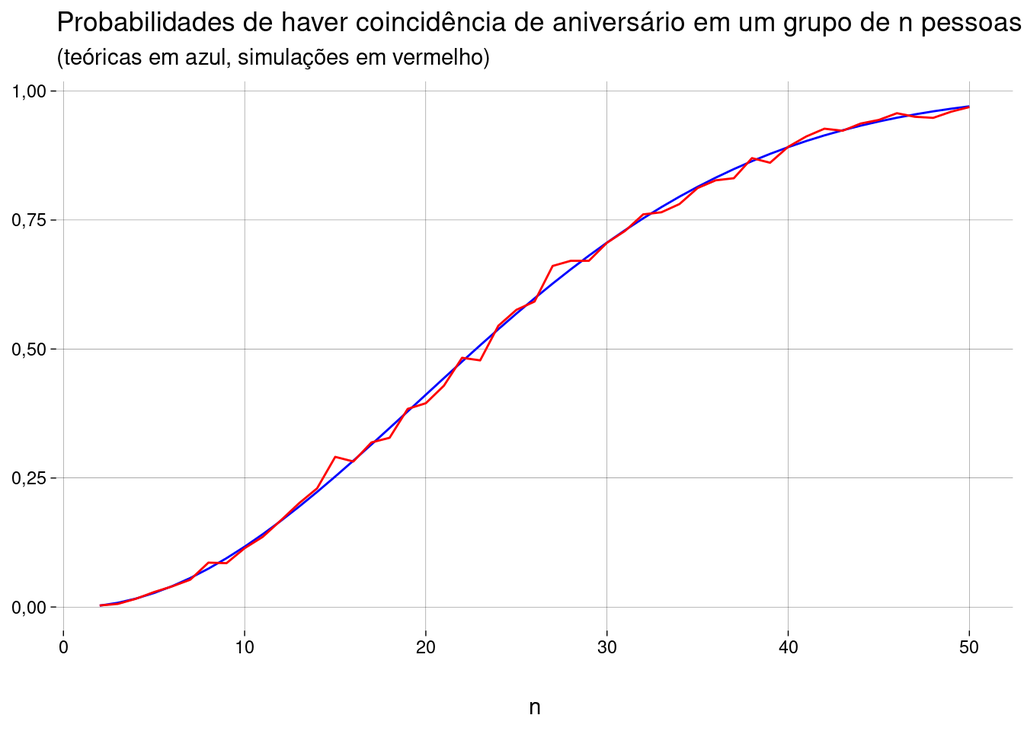

```r
nsalas <- 1e3
npessoas <- 2:50

probs_sim <- sapply(npessoas, simular, nsalas)

grafico +
  geom_line(
    data = as_tibble(probs_sim),
    mapping = aes(y = value),
    color = 'red'
  ) +
  labs(
    subtitle = '(teóricas em azul, simulações em vermelho)'
  )
```

## 10.5 Premissas mais realistas

- Vamos considerar anos bissextos. O total de dias muda para 366, mas um dos dias tem $1/4$ da probabilidade dos outros de ser o aniversário de alguém.
- Vamos supor que haja 165 dias em que a probabilidade de alguém nascer é 25% maior do que nos outros 201 dias.
- A solução teórica é bem mais complexa do que no caso uniforme!

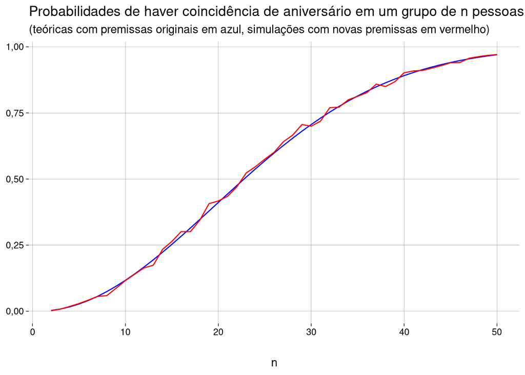

```r
nsalas <- 1e3
npessoas <- 2:50

pesos <- c(
  rep(4, 200),    # dias normais
  rep(5, 165),    # dias mais prováveis
  1               # 29 de fevereiro
)

testar_sala <- function(npessoas, pesos) {

  sala <- sample(1:366, npessoas, replace = TRUE, prob = pesos)
  coincidencia(sala)

}

simular <- function(npessoas, nsalas, pesos) {

  resultados <- replicate(nsalas, testar_sala(npessoas, pesos))
  mean(resultados)

}

novas_probs <- sapply(npessoas, simular, nsalas, pesos)

grafico +
  geom_line(
    data = as_tibble(novas_probs),
    mapping = aes(y = value),
    color = 'red'
  ) +
  labs(
    subtitle = '(teóricas com premissas originais em azul, simulações com novas premissas em vermelho)'
  )
```

# 11 Exercícios

## 11.1 Semanas com mais nascimentos

Imagine que 50% dos nascimentos de um ano aconteçam em um período de 15 semanas, e o restante dos nascimentos seja distribuído de maneira uniforme no restante do ano. Ignore anos bissextos.

Faça simulações como na seção anterior ($2 \leq n \leq 50$) e construa o gráfico comparando com as probabilidades teóricas (com as premissas originais).

## 11.2 Pôquer

Uma mão de pôquer consiste de 5 cartas retiradas ao acaso de um baralho de 32 cartas (4 naipes, cada um com cartas 7, 8, 9, 10, J, Q, K, A).

Calcule as seguintes probabilidades teoricamente e através de simulações.

1. Qual a probabilidade de obter uma mão sem ases?
2. Qual a probabilidade de obter 4 ases?
3. Qual a probabilidade de obter uma sequência (7 a J, 8 a Q, 9 a K, ou 10 a A) de naipes quaisquer?
4. Qual a probabilidade de obter uma sequência (7 a J, 8 a Q, 9 a K, ou 10 a A) do mesmo naipe?

## 11.3 Dados

Calcule as seguintes probabilidades teoricamente e através de simulações.

1. Você lança um dado não-viciado 6 vezes. Qual a probabilidade de que saiam os 6 números?
2. Idem, se você lançar o dado 10 vezes.
3. Repita os 2 itens acima, para um dado viciado, no qual
   $$P(1) = \frac{1}{12}, \quad P(2) = P(3) = P(4) = P(5) = \frac{1}{6}, \quad P(6) = \frac{3}{12}$$